# Financial Statistics Homework1

Chen Xupeng

# 1

$$\begin{array} { l } { \left( 10 ^ { \prime } \right) \text { Generate a random sample of size } 100 \text { from the } t \text { -distribution with } \nu \text { degrees of } } \\ { \text { freedom for } \nu = 5,15 \text { and } \infty ( \text { i.e., normal distribution). Apply the Jarque-Bera test to } } \\ { \text { check for the normality and report the } p \text { -values. } } \end{array}$$

```r
library(tseries)
set.seed(100)
sample_t_5 = rt(100,5,ncp=0)
sample_t_10 = rt(100,10,ncp=0)
sample_norm = rnorm(1000,0,1)
jarque.bera.test(sample_t_5)
```

```
##
##  Jarque Bera Test
##
## data:  sample_t_5
## X-squared = 28.058, df = 2, p-value = 8.077e-07
```

```r
jarque.bera.test(sample_t_10)
```

```
##
##  Jarque Bera Test
##
## data:  sample_t_10
## X-squared = 3.5564, df = 2, p-value = 0.1689
```

```r
jarque.bera.test(sample_norm)
```

```
##
##  Jarque Bera Test
##
## data:  sample_norm
## X-squared = 1.5837, df = 2, p-value = 0.453
```

We do not reject the null hypothesis of normality for the series of t-distribution with freedom 10 and $\infty$, but reject the null hypothesis and assume that freedom 5 t-distribution is not under normal assumption.

# 2

log price $\log S _ { t } = \log S _ { t - 1 } + r _ { t }$ is a random walk.

# 3

(10’) If the Ljung-Box test is employed to test the efﬁcient market hypothesis, what null hypothesis is to be tested? If the autocorrelation for the ﬁrst 4 lags of the monthly log-returns of the S&P 500 is $\widehat { \rho } _ { 1 } = 0.2 , \quad \widehat { \rho } _ { 2 } = - 0.15 , \quad \widehat { \rho } _ { 3 } = 0.25 , \quad \widehat { \rho } _ { 4 } = 0.12$, based on past 5 years data, is the efﬁcient market hypothesis reasonable?

null hypothesis: the m coefficients of Autocorrelation are simultaneously zero we have the

$$Q_{LB} = n(n+2)\sum_{k=1}^m \frac{\rho_k}{n-k} \sim X^2_{m.d.f}$$
$Q_{LB} = 12*14*(0.2/11-0.15/10+0.25/9+0.12/8) $

```r
Q_lb = 12*14*(0.2/11-0.15/10+0.25/9+0.12/8)
pchisq(Q_lb, df=4, lower.tail=FALSE)
```

```
## [1] 0.1023412
```

p-value is bigger than 0.05, we do not reject the null hypothesis that the m coefficients of Autocorrelation are simultaneously zero, the efﬁcient market hypothesis reasonable.

# 4

(20’) Suppose that a stock return follows the nonlinear dynamic
$$X _ { t } = \varepsilon _ { t } + \frac { 0.8 \varepsilon _ { t - 1 } ^ { 2 } } { 1 + \varepsilon _ { t - 1 } ^ { 2 } }$$

(a). Simulate the time series of length 1000 with $\sigma$ = 1, and show the plots of ACF and PACF.

```r
library('forecast')
```

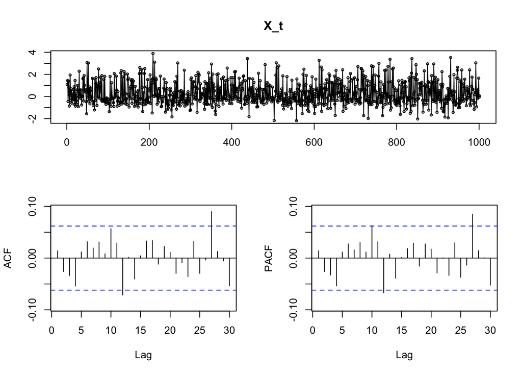

```r
rand.gen = rnorm(1001)
X_t = rand.gen[1:1001]+0.8*rand.gen**2/(1+rand.gen**2)
tsdisplay(X_t, plot.type = "partial")
```

(b). Show that the ACF of ${X_t }$ is zero except at lag 0;
$$\delta(h) = \frac{\gamma(h)}{\gamma(0)}, \text{where} \gamma(h), \gamma(0) \text{ are auto covariance and varaince}\\
E(X_t) = \frac{0.8 E(\epsilon^2_{t-1})}{1+E(\varepsilon^2_{t-1})} + E(\varepsilon_{t})\\
= \frac{0.8\sigma^2}{1+\sigma^2}+0\\
\gamma(0) = Var(X_t) = \frac{0.8 Var (\varepsilon^2_{t-1})}{1+Var(\varepsilon^2_{t-1})} + \sigma^2\\
E(\varepsilon^2_{t-1} )= Var(\varepsilon_{t-1})+[E(\varepsilon_{t-1})]^2 = \sigma^2\\
cov(X_t,X_{t+1}) = cov(\varepsilon _ { t } + \frac { 0.8 \varepsilon _ { t - 1 } ^ { 2 } } { 1 + \varepsilon _ { t - 1 } ^ { 2 } },\varepsilon _ { t+1 } + \frac { 0.8 \varepsilon _ { t } ^ { 2 } } { 1 + \varepsilon _ { t } ^ { 2 } }) = 0.8 cov(\epsilon_t, \frac { \varepsilon _ { t - 1 } ^ 2}{1+\varepsilon _ { t - 1 }}) = 0\\
\text{similarly we have} cov(X_t,X_{t+2}) = 0\\
\text{ACF is: 1 if h=0, else: ACF=0}$$

(c). Use (b) to show that the PACF of ${X_t }$ is zero. For PACF:
$$\sigma_{kk} = \frac{f_k-\sum_{j=1}^{k-1}\alpha_{k-1,j}f(k-j)}{1-\sum_{j=1}^{k-1}\alpha_{k-1,j}f(j)}\\
\sigma_{kj} = \alpha_{k-1,j}-\alpha_{kk},\alpha_{k-1,j-1}\\
\alpha_{11} = \alpha_{22} = \alpha_{12} = 0\\$$
So we have PACF is zero.

This example shows that ACF and PACF are useful mainly for linear time series.

# 5

## a

$$p \left( x _ { t } | x _ { t - 1 }, ..., x_1 \right) = N \left( \sum_{i=1}^{t-1} \phi x _ p , \sigma^2 \right)$$

## b

```r
sigma=1
x0=1
x1=1
x=2
epsilon <- rnorm(1000)
```

## c

1. usually we can use AIC and BIC to determine p.
   $$\operatorname { AIC } ( k ) = \ln \tilde { \sigma } _ { k } ^ { 2 } + \frac { 2 k } { T }\\
   \mathrm { BIC } ( k ) = \ln \tilde { \sigma } _ { k } ^ { 2 } + \frac { k \ln T } { T }$$
2. We can use OLS, EM algorithm, Yule- Walker recursion and Burg recursion, etc to estimate parameters.
3. Box-Ljung test to test $\varepsilon _ { t } \sim \mathcal { N } \left( 0 , \sigma ^ { 2 } \right)$
4. Use $R^2$ to check goodness of fit
   $$R ^ { 2 } = 1 - \frac { \sum _ { t = p + 1 } ^ { T } e _ { t } ^ { 2 } } { \sum _ { t = p + 1 } ^ { T } \left( x _ { t } - \overline { x } \right) ^ { 2 } }\\
   \overline { x } = \frac { 1 } { T - p } \sum _ { t = p + 1 } ^ { T } x _ { t }$$